# STAT 440 Statistical Data Management - Spring 2022

## Week03 Lab01 Wed

### Both .Rmd and .html files must be submitted by the end of class plus a 10 minute grace period. Any lab submitted after that 10 minute grace period will be deducted 2 points for being late. Labs submitted after the lab solution is posted will not be accepted; resulting in a 0 for that driver’s lab.

#### Only the driver should submit this assignment into their individual student repo. Save the filename as lab01-week03-section02-wed-netID.Rmd and render this file to .html.

**#1** (Syllabus, Markdown) Using Markdown syntax, make a numbered list with the first and last names of everyone at your station. Your name should appear in bold text.

**Answer:** Answers will vary, but must be a proper list with Driver’s name in bold text.

**#2** (Accessing and importing data, Markdown)

statement: When importing a semi-structured dataset, we can use RStudio’s Import Dataset Wizard.

If the statement is true, then write TRUE below in all caps. Otherwise write FALSE in all caps.

**Answer:** FALSE

**#3** (Accessing and importing data) Import the Urbana Community Development Permits Issued Data using its URL https://uofi.box.com/shared/static/l5azidzmgnnhh6xyhs2ngchpum5uu5bg.csv such that your resulting data structure matches the structure in the image below. **You must print the structure of your data.**

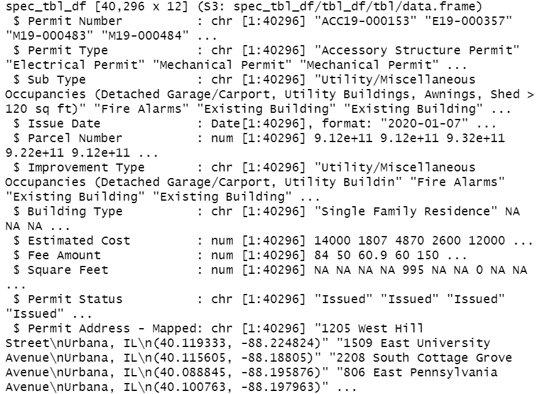

img03

**Answer:**

```r
library(tidyverse)
permit <- read_csv("https://uofi.box.com/shared/static/l5azidzmgnnhh6xyhs2ngchpum5uu5bg.csv",
    col_types = cols(`Issue Date` = col_date(format = "%m/%d/%Y")))
str(permit)
```

```
## spec_tbl_df [40,296 x 12] (S3: spec_tbl_df/tbl_df/tbl/data.frame)
##  $ Permit Number          : chr [1:40296] "ACC19-000153" "E19-000357" "M19-000483" "M19-000484" ...
##  $ Permit Type            : chr [1:40296] "Accessory Structure Permit" "Electrical Permit" "Mechanical Permit" "Mechanical Permit" ...
##  $ Sub Type               : chr [1:40296] "Utility/Miscellaneous Occupancies (Detached Garage/Carport, Utility Buildings, Awnings, Shed > 120 sq ft)" "Fire Alarms" "Existing Building" "Existing Building" ...
##  $ Issue Date             : Date[1:40296], format: "2020-01-07" "2020-01-03" ...
##  $ Parcel Number          : num [1:40296] 9.12e+11 9.12e+11 9.32e+11 9.22e+11 9.12e+11 ...
##  $ Improvement Type       : chr [1:40296] "Utility/Miscellaneous Occupancies (Detached Garage/Carport, Utility Buildin" "Fire Alarms" "Existing Building" "Existing Building" ...
##  $ Building Type          : chr [1:40296] "Single Family Residence" NA NA NA ...
##  $ Estimated Cost         : num [1:40296] 14000 1807 4870 2600 12000 ...
##  $ Fee Amount             : num [1:40296] 84 50 60.9 60 150 ...
##  $ Square Feet            : num [1:40296] NA NA NA NA 995 NA NA 0 NA NA ...
##  $ Permit Status          : chr [1:40296] "Issued" "Issued" "Issued" "Issued" ...
##  $ Permit Address - Mapped: chr [1:40296] "1205 West Hill Street\nUrbana, IL\n(40.119333, -88.224824)" "1509 East University Avenue\nUrbana, IL\n(40.115605, -88.18805)" "2208 South Cottage Grove Avenue\nUrbana, IL\n(40.088845, -88.195876)" "806 East Pennsylvania Avenue\nUrbana, IL\n(40.100763, -8…
##  - attr(*, "spec")=
##   .. cols(
##   ..   `Permit Number` = col_character(),
##   ..   `Permit Type` = col_character(),
##   ..   `Sub Type` = col_character(),
##   ..   `Issue Date` = col_date(format = "%m/%d/%Y"),
##   ..   `Parcel Number` = col_double(),
##   ..   `Improvement Type` = col_character(),
##   ..   `Building Type` = col_character(),
##   ..   `Estimated Cost` = col_double(),
##   ..   `Fee Amount` = col_double(),
##   ..   `Square Feet` = col_double(),
##   ..   `Permit Status` = col_character(),
##   ..   `Permit Address - Mapped` = col_character()
##   .. )
##  - attr(*, "problems")=<externalptr>
```

**#4** (Accessing and importing data) Import the Rental Inspection Grades Listing Data using its URL https://data.urbanaillinois.us/api/views/tn7v-fm2b/rows.csv?accessType=DOWNLOAD, print the structure of the data, and ensure the 2 dates columns are formatted properly as dates in R. This structure should match the data description below.

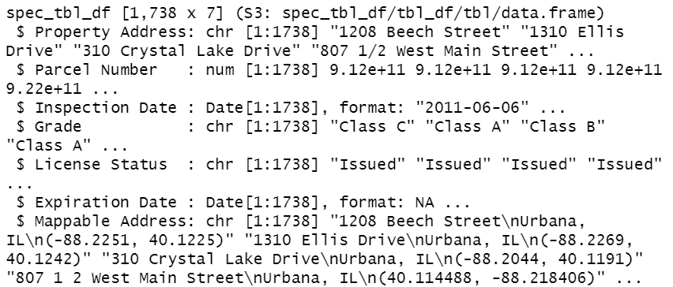

img04

**Answer:**

```r
rental <- read_csv("https://data.urbanaillinois.us/api/views/tn7v-fm2b/rows.csv?accessType=DOWNLOAD",
    col_types = cols(`Inspection Date` = col_date(format = "%m/%d/%Y"),
        `Expiration Date` = col_date(format = "%m/%d/%Y")))
str(rental)
```

```
## spec_tbl_df [1,738 x 7] (S3: spec_tbl_df/tbl_df/tbl/data.frame)
##  $ Property Address: chr [1:1738] "1208 Beech Street" "1310 Ellis Drive" "310 Crystal Lake Drive" "807 1/2 West Main Street" ...
##  $ Parcel Number   : num [1:1738] 9.12e+11 9.12e+11 9.12e+11 9.12e+11 9.22e+11 ...
##  $ Inspection Date : Date[1:1738], format: "2011-06-06" "2011-12-20" ...
##  $ Grade           : chr [1:1738] "Class C" "Class A" "Class B" "Class A" ...
##  $ License Status  : chr [1:1738] "Issued" "Issued" "Issued" "Issued" ...
##  $ Expiration Date : Date[1:1738], format: NA NA ...
##  $ Mappable Address: chr [1:1738] "1208 Beech Street\nUrbana, IL\n(-88.2251, 40.1225)" "1310 Ellis Drive\nUrbana, IL\n(-88.2269, 40.1242)" "310 Crystal Lake Drive\nUrbana, IL\n(-88.2044, 40.1191)" "807 1 2 West Main Street\nUrbana, IL\n(40.114488, -88.218406)" ...
##  - attr(*, "spec")=
##   .. cols(
##   ..   `Property Address` = col_character(),
##   ..   `Parcel Number` = col_double(),
##   ..   `Inspection Date` = col_date(format = "%m/%d/%Y"),
##   ..   Grade = col_character(),
##   ..   `License Status` = col_character(),
##   ..   `Expiration Date` = col_date(format = "%m/%d/%Y"),
##   ..   `Mappable Address` = col_character()
##   .. )
##  - attr(*, "problems")=<externalptr>
```

**#5** (Accessing and importing data via web scraping, Markdown) Select all of the following properties that had a Board of Review level of assessment larger than 50,000:

1. 922117132002
2. 922116306002
3. 912108352008
4. 922116108008
5. 912107280008

Web scrape the Champaign County Assessor’s [website](https://champaignil.devnetwedge.com/) for these properties and print results to show evidence of your answer.

**Answer:** Property a had a Board of Review level of assessment larger than 50,000.

```r
library(rvest)
pns <- c(922117132002,922116306002,912108352008,922116108008,912107280008)

prop_url <- paste0("https://champaignil.devnetwedge.com/parcel/view/",pns,"/2021")

board <- rep(NA, length(prop_url))

board[1] <- html_text(html_nodes(read_html(prop_url[1]), ".text-right:nth-child(1) td:nth-child(7)"),trim=TRUE)
board[2] <- html_text(html_nodes(read_html(prop_url[2]), ".text-right:nth-child(1) td:nth-child(7)"),trim=TRUE)
board[3] <- html_text(html_nodes(read_html(prop_url[3]), ".text-right:nth-child(1) td:nth-child(7)"),trim=TRUE)
board[4] <- html_text(html_nodes(read_html(prop_url[4]), ".text-right:nth-child(1) td:nth-child(7)"),trim=TRUE)
board[5] <- html_text(html_nodes(read_html(prop_url[5]), ".text-right:nth-child(1) td:nth-child(7)"),trim=TRUE)

board
```

```
## [1] "51,380" "23,170" "17,750" "29,680" "14,280"
```